# DATA_621_Blog_2

Euclid Zhang

4/4/2022

# Multivariate Linear Regression

In Blog 1 we see a simple example of linear regression with 1 predictor variable. In real world, mostly we would like to know the outcome of an event related to multiple variables instead of one. Building a model with multiple predictor variables is called the multivariate linear regression. It follows the same process as the simple linear regression. However, multivariate linear regression is generally more complicated as we need to consider transforming the predictor variables or adding interactions between the predictor variables to make the model fit the data while meeting all the assumptions of the model.

# Fuel efficiency of cars

When buying a car, fuel efficiency is one of the most important factors in comparing different car models. We would like to have a car running more miles per gallon of fuel. Here we will build a multivariate linear regression model to see what characteristics (horse power, weight, etc.) of a car affact its fuel efficiency.

The data used is from https://archive.ics.uci.edu/ml/datasets/auto+mpg

This dataset was taken from the StatLib library which is maintained at Carnegie Mellon University. The dataset was used in the 1983 American Statistical Association Exposition.

```r
df <- read.csv("auto-mpg.csv", stringsAsFactors = TRUE)
names(df)[1] <- "miles_per_gallon"
```

The data set contains the following fields:

- mpg: fuel efficiency measured in miles per gallon
- cylinders: number of cylinders in the engine
- displacement: engine displacement in cubic inches
- horsepower: engine horsepower
- weight: vehicle weight in pounds
- acceleration: the number of seconds to accelerate from 0 to 60 mph
- model year: the model year of the vehicle
- origin: the origin of the car, American, European or Japanses
- car name: the name of the car

```r
summary(df)
```

```
##  miles_per_gallon   cylinders      displacement     horsepower
##  Min.   : 9.00    Min.   :3.000   Min.   : 68.0   Min.   : 46.0
##  1st Qu.:17.50    1st Qu.:4.000   1st Qu.:104.2   1st Qu.: 75.0
##  Median :23.00    Median :4.000   Median :148.5   Median : 93.5
##  Mean   :23.51    Mean   :5.455   Mean   :193.4   Mean   :104.5
##  3rd Qu.:29.00    3rd Qu.:8.000   3rd Qu.:262.0   3rd Qu.:126.0
##  Max.   :46.60    Max.   :8.000   Max.   :455.0   Max.   :230.0
##                                                   NA's   :6
##      weight      acceleration     model_year         origin
##  Min.   :1613   Min.   : 8.00   Min.   :70.00   American:249
##  1st Qu.:2224   1st Qu.:13.82   1st Qu.:73.00   European: 70
##  Median :2804   Median :15.50   Median :76.00   Japanese: 79
##  Mean   :2970   Mean   :15.57   Mean   :76.01
##  3rd Qu.:3608   3rd Qu.:17.18   3rd Qu.:79.00
##  Max.   :5140   Max.   :24.80   Max.   :82.00
##
##            car_name
##  ford pinto    :  6
##  amc matador   :  5
##  ford maverick :  5
##  toyota corolla:  5
##  amc gremlin   :  4
##  amc hornet    :  4
##  (Other)       :369
```

There are 6 missing values in horsepower, we will impute them with the mean value of horsepower.  
Since the data was used in 1983, we will calculate the age of the cars by 1983 - the model year. The mode year and the name of the cars will then not included in our model.

```r
df2 <- df
df2$horsepower[is.na(df2$horsepower)] <- mean(df2$horsepower, na.rm = TRUE)
df2$car_age <- 83-df2$model_year
df2$model_year<- NULL
df2$car_name <- NULL
```

The data is ready, let’s build our first model including all variables

```r
lm_model <- lm(miles_per_gallon~., df2)
```

```r
summary(lm_model)
```

```
##
## Call:
## lm(formula = miles_per_gallon ~ ., data = df2)
##
## Residuals:
##     Min      1Q  Median      3Q     Max
## -8.9327 -2.0491 -0.0908  1.9473 13.3511
##
## Coefficients:
##                  Estimate Std. Error t value Pr(>|t|)
## (Intercept)    46.2101599  2.0717583  22.305  < 2e-16 ***
## cylinders      -0.4208161  0.3192205  -1.318  0.18819
## displacement    0.0236165  0.0076225   3.098  0.00209 **
## horsepower     -0.0133577  0.0130711  -1.022  0.30745
## weight         -0.0069660  0.0006415 -10.858  < 2e-16 ***
## acceleration    0.0995709  0.0953196   1.045  0.29686
## originEuropean  2.7825588  0.5567695   4.998 8.79e-07 ***
## originJapanese  2.8277261  0.5452849   5.186 3.47e-07 ***
## car_age        -0.7842134  0.0509285 -15.398  < 2e-16 ***
## ---
## Signif. codes:  0 '***' 0.001 '**' 0.01 '*' 0.05 '.' 0.1 ' ' 1
##
## Residual standard error: 3.308 on 389 degrees of freedom
## Multiple R-squared:  0.8245, Adjusted R-squared:  0.8209
## F-statistic: 228.4 on 8 and 389 DF,  p-value: < 2.2e-16
```

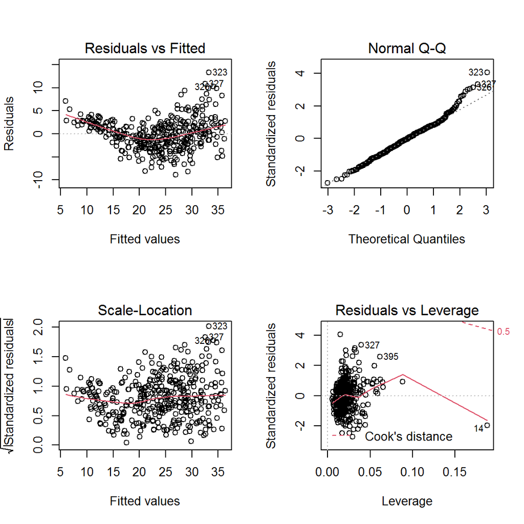

```r
par(mfrow=c(2,2))
plot(lm_model)
```

Apparently there is a pattern in the residuals. The relationship is non-linear.  
From the Scale-Location plot, the residuals do not have constant variance.  
We may consider transforming the response variable. Let’s look at the distribution of the response variable

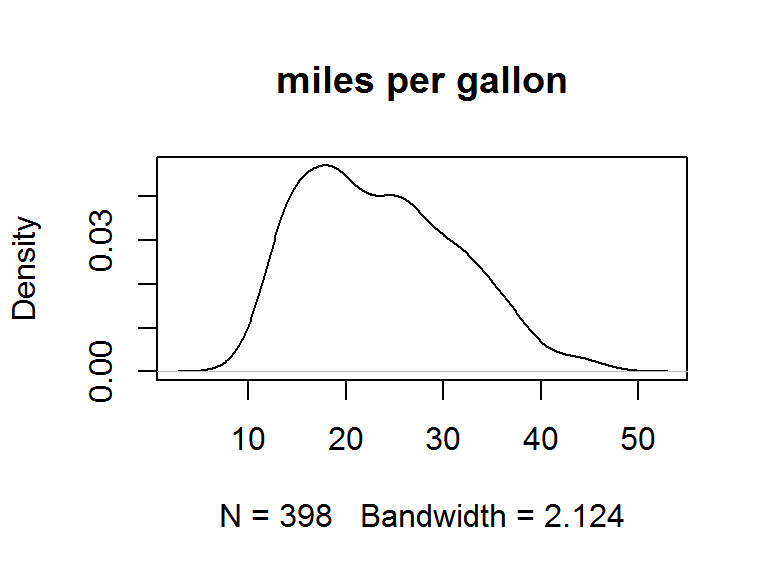

```r
plot(density(df2$miles_per_gallon), main="miles per gallon")
```

The distribution is right skewed, a log transformation may be applied to the variable

We rebuild our model with the log-transformed miles_per_gallon

```r
lm_model <- lm(log(miles_per_gallon)~., df2)
```

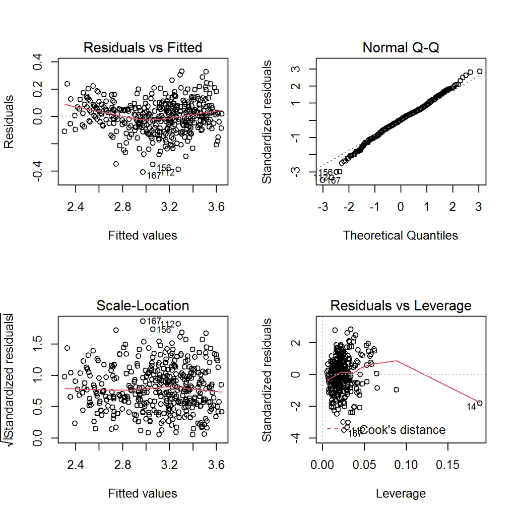

```r
par(mfrow=c(2,2))
plot(lm_model)
```

The variance of the residuals are now constant. The distribution of the residuals is approximately normal, except a few outliers. However, the is still a little curvature in the Residuals vs Fitted plot.

We may consider transforming one or more of the predictor variables, or adding interactions between variables.

One may want to know if any of the predictor variables have a different effect on the outcome (mile_per_gallon) depending on the value of the origin (American, Japanese or European).

We will first add the interactions between origin and all other predictor variables. If the residuals are still showing non-linear relationship, we would do more transformation of the predictor variables.

```r
lm_model <- lm(log(miles_per_gallon)~.*origin, df2)
```

```r
summary(lm_model)
```

```
##
## Call:
## lm(formula = log(miles_per_gallon) ~ . * origin, data = df2)
##
## Residuals:
##      Min       1Q   Median       3Q      Max
## -0.38033 -0.06519  0.00531  0.06485  0.41771
##
## Coefficients:
##                               Estimate Std. Error t value Pr(>|t|)
## (Intercept)                  4.450e+00  8.658e-02  51.400  < 2e-16 ***
## cylinders                   -3.892e-02  1.228e-02  -3.170 0.001646 **
## displacement                 5.644e-05  2.999e-04   0.188 0.850806
## horsepower                  -1.362e-03  4.905e-04  -2.776 0.005771 **
## weight                      -1.906e-04  2.659e-05  -7.166 4.10e-12 ***
## acceleration                -1.725e-02  4.238e-03  -4.070 5.73e-05 ***
## originEuropean              -1.231e-01  1.999e-01  -0.616 0.538331
## originJapanese              -2.430e-01  2.422e-01  -1.003 0.316436
## car_age                     -2.800e-02  2.264e-03 -12.367  < 2e-16 ***
## cylinders:originEuropean    -6.977e-03  3.820e-02  -0.183 0.855160
## cylinders:originJapanese     4.668e-02  3.610e-02   1.293 0.196839
## displacement:originEuropean -8.628e-04  1.509e-03  -0.572 0.567856
## displacement:originJapanese  2.374e-03  1.436e-03   1.653 0.099169 .
## horsepower:originEuropean   -3.507e-04  1.374e-03  -0.255 0.798715
## horsepower:originJapanese   -2.518e-04  2.228e-03  -0.113 0.910097
## weight:originEuropean       -4.025e-05  7.747e-05  -0.520 0.603706
## weight:originJapanese       -2.393e-04  1.202e-04  -1.990 0.047305 *
## acceleration:originEuropean  3.033e-02  8.297e-03   3.656 0.000293 ***
## acceleration:originJapanese  2.710e-02  1.142e-02   2.374 0.018118 *
## originEuropean:car_age      -9.400e-03  4.674e-03  -2.011 0.045005 *
## originJapanese:car_age      -2.429e-03  4.915e-03  -0.494 0.621395
## ---
## Signif. codes:  0 '***' 0.001 '**' 0.01 '*' 0.05 '.' 0.1 ' ' 1
##
## Residual standard error: 0.1114 on 377 degrees of freedom
## Multiple R-squared:  0.8979, Adjusted R-squared:  0.8925
## F-statistic: 165.8 on 20 and 377 DF,  p-value: < 2.2e-16
```

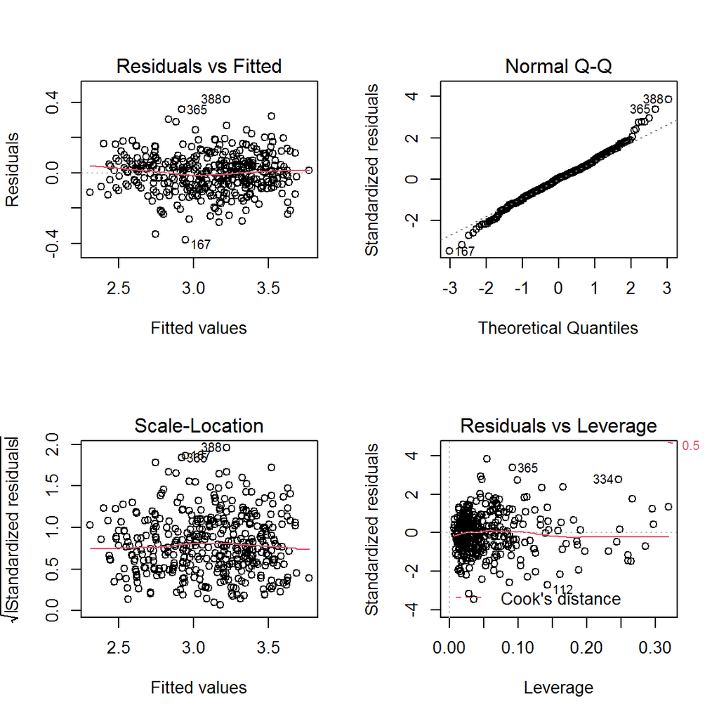

```r
par(mfrow=c(2,2))
plot(lm_model)
```

Luckily, the relationship now is approximately linear.

Let’s look at the summary of our model

```r
summary(lm_model)
```

```
##
## Call:
## lm(formula = log(miles_per_gallon) ~ . * origin, data = df2)
##
## Residuals:
##      Min       1Q   Median       3Q      Max
## -0.38033 -0.06519  0.00531  0.06485  0.41771
##
## Coefficients:
##                               Estimate Std. Error t value Pr(>|t|)
## (Intercept)                  4.450e+00  8.658e-02  51.400  < 2e-16 ***
## cylinders                   -3.892e-02  1.228e-02  -3.170 0.001646 **
## displacement                 5.644e-05  2.999e-04   0.188 0.850806
## horsepower                  -1.362e-03  4.905e-04  -2.776 0.005771 **
## weight                      -1.906e-04  2.659e-05  -7.166 4.10e-12 ***
## acceleration                -1.725e-02  4.238e-03  -4.070 5.73e-05 ***
## originEuropean              -1.231e-01  1.999e-01  -0.616 0.538331
## originJapanese              -2.430e-01  2.422e-01  -1.003 0.316436
## car_age                     -2.800e-02  2.264e-03 -12.367  < 2e-16 ***
## cylinders:originEuropean    -6.977e-03  3.820e-02  -0.183 0.855160
## cylinders:originJapanese     4.668e-02  3.610e-02   1.293 0.196839
## displacement:originEuropean -8.628e-04  1.509e-03  -0.572 0.567856
## displacement:originJapanese  2.374e-03  1.436e-03   1.653 0.099169 .
## horsepower:originEuropean   -3.507e-04  1.374e-03  -0.255 0.798715
## horsepower:originJapanese   -2.518e-04  2.228e-03  -0.113 0.910097
## weight:originEuropean       -4.025e-05  7.747e-05  -0.520 0.603706
## weight:originJapanese       -2.393e-04  1.202e-04  -1.990 0.047305 *
## acceleration:originEuropean  3.033e-02  8.297e-03   3.656 0.000293 ***
## acceleration:originJapanese  2.710e-02  1.142e-02   2.374 0.018118 *
## originEuropean:car_age      -9.400e-03  4.674e-03  -2.011 0.045005 *
## originJapanese:car_age      -2.429e-03  4.915e-03  -0.494 0.621395
## ---
## Signif. codes:  0 '***' 0.001 '**' 0.01 '*' 0.05 '.' 0.1 ' ' 1
##
## Residual standard error: 0.1114 on 377 degrees of freedom
## Multiple R-squared:  0.8979, Adjusted R-squared:  0.8925
## F-statistic: 165.8 on 20 and 377 DF,  p-value: < 2.2e-16
```

we see that some of the coefficients are not significant. We will remove some of the terms by based on the significancy.

```r
lm_model2 <- ols_step_both_p(lm_model, details = FALSE)$model
```

Our final model is

```r
summary(lm_model2)
```

```
##
## Call:
## lm(formula = paste(response, "~", paste(preds, collapse = " + ")),
##     data = l)
##
## Residuals:
##      Min       1Q   Median       3Q      Max
## -0.37275 -0.07317  0.00523  0.06875  0.37213
##
## Coefficients:
##                            Estimate Std. Error t value Pr(>|t|)
## (Intercept)               4.174e+00  4.904e-02  85.120  < 2e-16 ***
## weight                   -2.381e-04  2.379e-05 -10.007  < 2e-16 ***
## car_age                  -2.774e-02  2.342e-03 -11.845  < 2e-16 ***
## originEuropean            4.112e-01  1.383e-01   2.973  0.00314 **
## originJapanese            1.661e-01  1.172e-01   1.417  0.15735
## horsepower               -1.054e-03  3.773e-04  -2.795  0.00546 **
## displacement              5.472e-04  2.862e-04   1.912  0.05658 .
## originAmerican:cylinders -3.620e-02  1.251e-02  -2.894  0.00402 **
## originEuropean:cylinders -7.326e-02  3.479e-02  -2.106  0.03588 *
## originJapanese:cylinders  3.934e-02  2.589e-02   1.519  0.12955
## weight:originEuropean    -3.733e-05  4.010e-05  -0.931  0.35244
## weight:originJapanese    -1.676e-04  5.170e-05  -3.242  0.00129 **
## car_age:originEuropean   -1.223e-02  4.750e-03  -2.576  0.01038 *
## car_age:originJapanese   -4.176e-03  4.305e-03  -0.970  0.33264
## ---
## Signif. codes:  0 '***' 0.001 '**' 0.01 '*' 0.05 '.' 0.1 ' ' 1
##
## Residual standard error: 0.1158 on 384 degrees of freedom
## Multiple R-squared:  0.8876, Adjusted R-squared:  0.8838
## F-statistic: 233.3 on 13 and 384 DF,  p-value: < 2.2e-16
```

# Conclusion

Based on the model

- cars with lighter weight have better fuel efficiency, given the origin is the same.
- cars of newer model have better fuel efficiency, given the origin is the same.
- The effect of car weight and car age is affected by the origin.
- cars made in European have better fuel efficiency.
- cars with lower horsepower have better fuel efficiency.
- cars with higher displacement have better fuel efficiency.
- American and European cars have better fuel efficiency with fewer cylinders.

From this example, we see that building a multivariate linear regression model is a lot more complicated than building a simple linear regression model. The Complexity increases as the number of predictor variables increases.

Another fact we need to be aware is that this is an old data set collected 1983. Our findings may not apply to the modern new cars. New data should be collected and the model should be revised.